# Import Module

```python
import numpy as np
import matplotlib.pyplot as plt
import pandas as pd
import yfinance as yf
yf.pdr_override()
import mplfinance as mpf
```

# Get Bitcoin Information (in USD)

```python
bitcoin_usd = yf.Ticker("BTC-USD")
bitcoin_usd.info
```

```
{'companyOfficers': [],
 'name': 'Bitcoin',
 'startDate': 1367107200,
 'description': 'Bitcoin (BTC) is a cryptocurrency . Users are able to generate BTC through the process of mining. Bitcoin has a current supply of 18,713,700. The last known price of Bitcoin is 41,866.04394382 USD and is up 18.21 over the last 24 hours. It is currently trading on 9556 active market(…
 'maxAge': 1,
 'previousClose': 37281.85,
 'regularMarketOpen': 37281.85,
 'twoHundredDayAverage': 39827.79,
 'trailingAnnualDividendYield': None,
 'payoutRatio': None,
 'volume24Hr': 91956846592,
 'regularMarketDayHigh': 42406.22,
 'navPrice': None,
 'averageDailyVolume10Day': 74141701821,
 'totalAssets': None,
 'regularMarketPreviousClose': 37281.85,
 'fiftyDayAverage': 55326.074,
 'trailingAnnualDividendRate': None,
 'open': 37281.85,
 'toCurrency': 'USD=X',
 'averageVolume10days': 74141701821,
 'expireDate': None,
 'yield': None,
 'algorithm': None,
 'dividendRate': None,
 'exDividendDate': None,
 'beta': None,
 'circulatingSupply': 18713700,
 'regularMarketDayLow': 35050.617,
 'priceHint': 2,
 'currency': 'USD',
 'regularMarketVolume': 91956846592,
 'lastMarket': 'CoinMarketCap',
 'maxSupply': None,
 'openInterest': None,
 'marketCap': 745299050496,
 'volumeAllCurrencies': 91956846592,
 'strikePrice': None,
 'averageVolume': 63972874733,
 'priceToSalesTrailing12Months': None,
```

[output cut: 12 more lines]

```
 'dividendYield': None,
 'bidSize': None,
 'dayHigh': 42406.22,
 'exchange': 'CCC',
 'shortName': 'Bitcoin USD',
 'exchangeTimezoneName': 'Europe/London',
 'exchangeTimezoneShortName': 'BST',
 'isEsgPopulated': False,
 'gmtOffSetMilliseconds': '3600000',
 'quoteType': 'CRYPTOCURRENCY',
 'symbol': 'BTC-USD',
 'messageBoardId': 'finmb_BTC_CCC',
 'market': 'ccc_market',
 'regularMarketPrice': 37281.85,
 'logo_url': ''}
```

## Fetch Historical Data

```python
# Valid period includes: 1d,5d,1mo,3mo,6mo,1y,2y,5y,10y,ytd,max
# Default is '1mo'

dataset = bitcoin_usd.history(period='1y')
```

## Check data

```python
dataset.head()
```

| Date | Open | High | Low | Close | Volume | Dividends | Stock Splits |
| --- | --- | --- | --- | --- | --- | --- | --- |
| 2020-05-20 | 9725.33 | 9804.79 | 9447.20 | 9522.98 | 36546239703 | 0 | 0 |
| 2020-05-21 | 9522.74 | 9555.24 | 8869.93 | 9081.76 | 39326160532 | 0 | 0 |
| 2020-05-22 | 9080.33 | 9232.94 | 9008.64 | 9182.58 | 29810773699 | 0 | 0 |
| 2020-05-23 | 9185.06 | 9302.50 | 9118.11 | 9209.29 | 27727866812 | 0 | 0 |
| 2020-05-24 | 9212.28 | 9288.40 | 8787.25 | 8790.37 | 32518803300 | 0 | 0 |

```python
dataset.tail()
```

| Date | Open | High | Low | Close | Volume | Dividends | Stock Splits |
| --- | --- | --- | --- | --- | --- | --- | --- |
| 2021-05-16 | 46716.64 | 49720.04 | 43963.35 | 46456.06 | 64047871555 | 0 | 0 |
| 2021-05-17 | 46415.90 | 46623.56 | 42207.29 | 43537.51 | 74903638450 | 0 | 0 |
| 2021-05-18 | 43488.06 | 45812.46 | 42367.83 | 42909.40 | 56187365084 | 0 | 0 |
| 2021-05-19 | 42944.98 | 43546.12 | 30681.50 | 37002.44 | 126358098747 | 0 | 0 |
| 2021-05-20 | 37281.85 | 42406.22 | 35050.62 | 39826.39 | 91956846592 | 0 | 0 |

```python
dataset.describe().T
```

|  | count | mean | std | min | 25% | 50% | 75% | max |
| --- | --- | --- | --- | --- | --- | --- | --- | --- |
| Open | 363.0 | 2.668546e+04 | 1.878678e+04 | 8.786110e+03 | 1.070735e+04 | 1.764519e+04 | 4.659320e+04 | 6.352375e+04 |
| High | 363.0 | 2.746950e+04 | 1.939019e+04 | 8.951010e+03 | 1.083063e+04 | 1.811955e+04 | 4.841713e+04 | 6.486310e+04 |
| Low | 363.0 | 2.582597e+04 | 1.804788e+04 | 8.719670e+03 | 1.058089e+04 | 1.691065e+04 | 4.514102e+04 | 6.220896e+04 |
| Close | 363.0 | 2.675965e+04 | 1.877479e+04 | 8.790370e+03 | 1.073344e+04 | 1.771741e+04 | 4.662065e+04 | 6.350346e+04 |
| Volume | 363.0 | 4.286923e+10 | 2.730459e+10 | 1.225260e+10 | 2.368586e+10 | 3.654624e+10 | 5.746058e+10 | 3.509679e+11 |
| Dividends | 363.0 | 0.000000e+00 | 0.000000e+00 | 0.000000e+00 | 0.000000e+00 | 0.000000e+00 | 0.000000e+00 | 0.000000e+00 |
| Stock Splits | 363.0 | 0.000000e+00 | 0.000000e+00 | 0.000000e+00 | 0.000000e+00 | 0.000000e+00 | 0.000000e+00 | 0.000000e+00 |

# Data Visualisation

- **Line chart** is a simple graphic display of price trends over time. It has one data point per time interval.
- **Bar chart** has four bits of data in each entry, which are the high and low price encountered during the imte interval, the opening and closing prices. From bar chart, analysts can immediately gets a sense of the nature of the time interval's trading.
- **Candlestick chart** also provides four prices per data point entry : the high and low prices, and the opening and closing prices during the period. The body of the candle is shaded or clear due to price difference of opening and closing. Compared to Bar Chart, Candlestick Chart is more visible.
- **Renko chart** looks like a series of bricks. A new brick is created when the price moves a specified price amount.
- **Point and figure chart** was widely used in US in the early 1900s. Neither time nor volume are represented in the chart. To draw the point and figure chart, we have to decide the box size and the reversal size.

## Line Chart

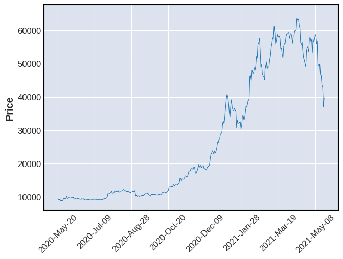

```python
mpf.plot(dataset, type='line')
```

## Bar Chart

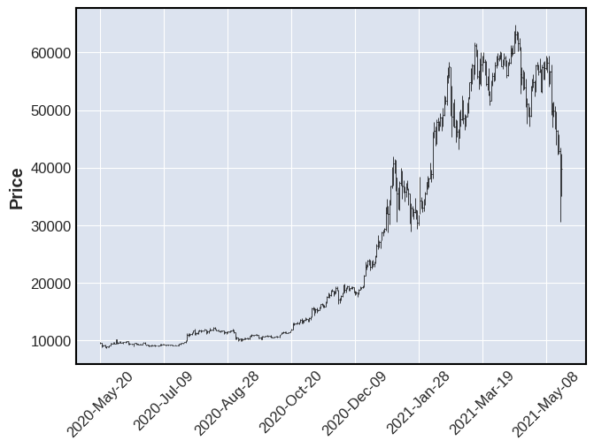

```python
mpf.plot(dataset)
```

### Concerning Specific Data Slice

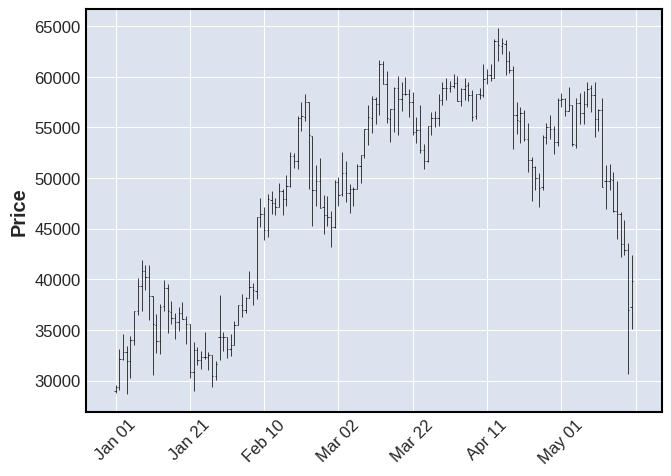

```python
mpf.plot(dataset['2021'])
```

## Candlestrik Chart

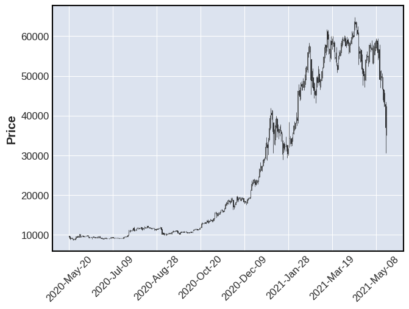

```python
mpf.plot(dataset, type='candle')
```

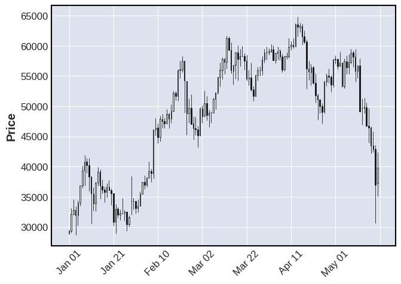

```python
mpf.plot(dataset['2021'], type='candle')
```

## Renko chart

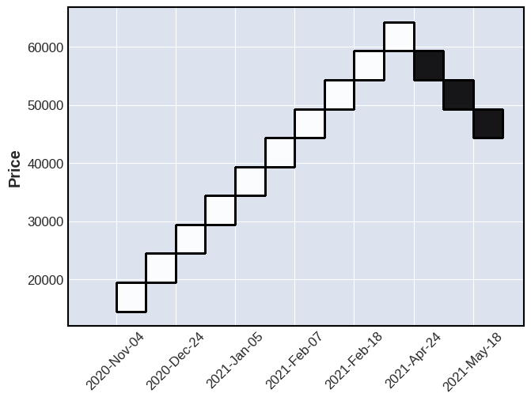

```python
mpf.plot(dataset, type='renko')
```

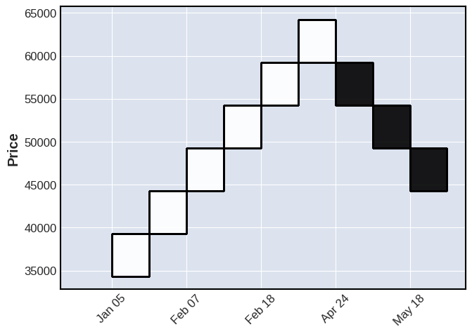

```python
mpf.plot(dataset['2021'], type='renko')
```

## Point and figure chart

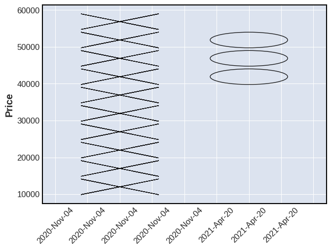

```python
mpf.plot(dataset, type='pnf')
```

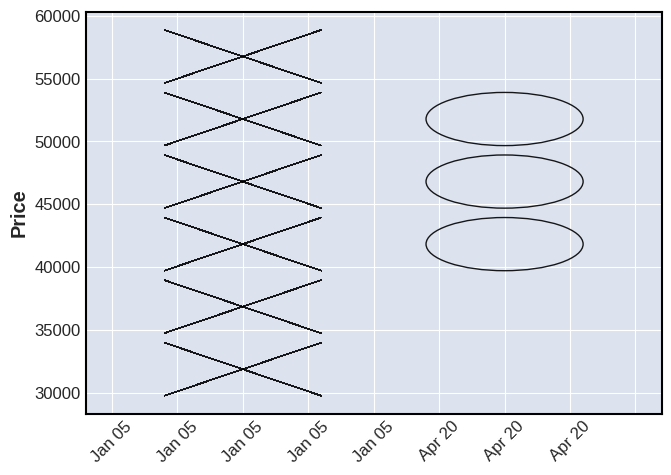

```python
mpf.plot(dataset['2021'], type='pnf')
```

# Further Analysis with Candlestick Chart

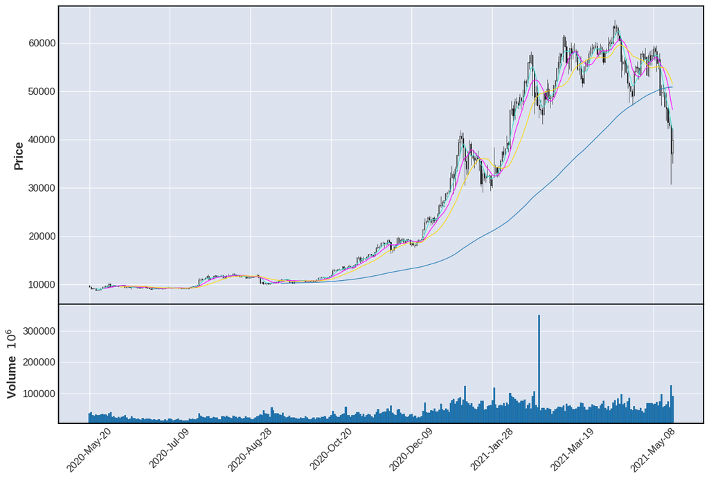

```python
mpf.plot(dataset,type='candle', figsize=(15,10),mav=(5,10,20,120),volume=True)
mpf.show()
```